# iborregog_DL_Practica

[figure not shown]

M2.875 · Deep Learning · Pràctica

2019-2 · Màster universitari en Ciència de dades (Data science)

Estudis d'Informàtica, Multimèdia i Telecomunicació

# Sistema automàtic per la detecció de COVID-19 en radiografies

Una de les applicacions de AI és el processament de imatges mèdiques. En particular, l'ús de les radiografies per una detecció no invasiva i ràpida del Covid-19 pot resultar extremadament útil per ajudar i agilitzar la tasca del personal mèdic [1][2].

En aquest projecte desenvoluparem un detector *Deep Learning* de Covid-19 en radiografies. Per això, utilitzarem imatges de la base de dades "Covid-chestxray-dataset" [3], generada per uns investigadors del grup de recerca [Mila](https://mila.quebec/en/) i de la Universitat de Montreal [4]. També farem servir imatges de radiogradies de pacients sans i amb pneumonia bacterial extretes de la competició de Kaggle "Chest X-Ray Images (Pneumonia)" [5].

En total, disposem d'un total de 426 imatges, dividides en conjunts d'entrenament (339 imatges), validació (42 imatges) i test (45 imatges). Les particions es donen en llistes ".txt", on a cada imatge se li assigna una etiqueta:

- 0) Healthy
- 1) Covid-19
- 2) Pneumonia

L'objectiu consisteix en desenvolupar un sistema basat en xarxes neuronals capaç de classificar correctament les imatges en aquestes 3 categories.

**Nota**: Els resultats obtinguts per models entrenats en aquesta base de dades són purament per finalitats educatives i no es poden fer servir per un diagnòstic real sense validació clínica.

#### Referències

1. María Climent, 2020 [Covid-19: La Inteligencia Artificial De La Española Quibim Puede Acelerar El Diagnóstico Del Coronavirus](https://innovadores.larazon.es/es/esta-inteligencia-artificial-espanola-puede-acelerar-el-diagnostico-del-coronavirus/)
2. Angel Alberich-bayarri,2020 [Imagin, AI and Radiomix to understand and fight Coronavirus Covid-19](https://quibim.com/2020/02/14/imaging-ai-and-radiomics-to-understand-and-fight-coronavirus-covid-19/)
3. [Ieee8023/covid-chestxray-dataset](https://github.com/ieee8023/covid-chestxray-dataset)
4. Cohen, J.P., Morrison, P. and Dao, L., 2020. [COVID-19 image data collection](https://arxiv.org/pdf/2003.11597.pdf).
5. Paul Mooney, 2019 [Chest X-ray Images (pneumonia)](https://www.kaggle.com/paultimothymooney/chest-xray-pneumonia)

#### Lectures recomanades

1. Souradip Chakraborty, 2020. [Detection Of Covid-19 Presence from Chest X-ray Scans Using Cnn & Class Activation Maps](https://towardsdatascience.com/detection-of-covid-19-presence-from-chest-x-ray-scans-using-cnn-class-activation-maps-c1ab0d7c294b)
2. Cohen, J.P., Hashir, M., Brooks, R. and Bertrand, H., 2020. [On the limits of cross-domain generalization in automated X-ray prediction](https://arxiv.org/pdf/2002.02497.pdf)
3. Karim, M., Döhmen, T., Rebholz-Schuhmann, D., Decker, S., Cochez, M. and Beyan, O., 2020. [Deepcovidexplainer: Explainable covid-19 predictions based on chest x-ray images](https://arxiv.org/pdf/2004.04582.pdf).
4. Wang, L., Wong, A. (2020). [COVID-Net: A Tailored Deep Convolutional Neural Network Design for Detection of COVID-19 Cases from Chest Radiography Images](https://arxiv.org/abs/2003.09871)
5. Zhou, B., Khosla, A., Lapedriza, A., Oliva, A. and Torralba, A., 2016. [Learning deep features for discriminative localization](https://arxiv.org/pdf/1512.04150.pdf). In Proceedings of the IEEE conference on computer vision and pattern recognition (pp. 2921-2929).
6. Mordvintsev, A., Olah, C. and Tyka, M., 2015. [Inceptionism: Going deeper into neural networks](https://ai.googleblog.com/2015/06/inceptionism-going-deeper-into-neural.html).

# Preparació del Dataset (3 punts)

En quest primer apartat s'analitzaran les imatges de la base de dades i es disenyarà un *pipeline* per carregar les imatges i preparar-les per la xarxa neuronal.

Caldrà tenir en compte factors com:

- Tamany d'entrada de les imatges
- Normalització de les imatges
- Visualitzacions d'algunes mostres per cadascuna de les classes
- Tècniques de *data augmentation* per augmentar el tamany del conjunt de dades

I, en general, qualsevol tècnica que considereu que pot millorar la implementació i resultats d'aquest projecte.

```python
import pandas as pd
import numpy as np
import matplotlib.pyplot as plt
from PIL import Image
```

```python
# Lectura dels fitxers i creació del datasets.

def datf(file,size):
    ftrain= open(file, 'r')
    ftrain= ftrain.read()
    ftrain= ftrain.split('\n')
    case=[]
    label=[]
    for i in ftrain[:-1]:
        c= i.split('\t')
        img= Image.open('DATASET/'+c[1]).convert('L') # mode luminositat (una sola dimensió en profunditat)
        img= np.array(img.resize(size))
        case.append(img)
        label.append(int(c[0]))
    return(pd.DataFrame({'Case': case, 'Label': label}).sample(frac=1,random_state=42).reset_index(drop=True))

size=(64,64) # tamany adequat per mantenir les caracteristiques originals
traindf= datf('DATASET/training.txt',size)
valdf  = datf('DATASET/validation.txt',size)
testdf = datf('DATASET/testing.txt',size)
```

```
Dos casos SANS____
```

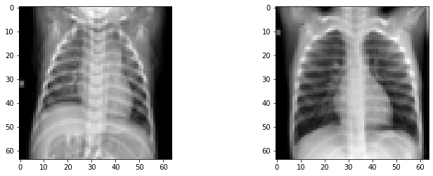

```
Dos casos amb COVID____
```

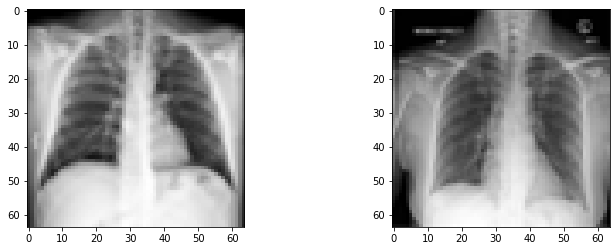

```
Dos casos amb PNEUMONIA____
```

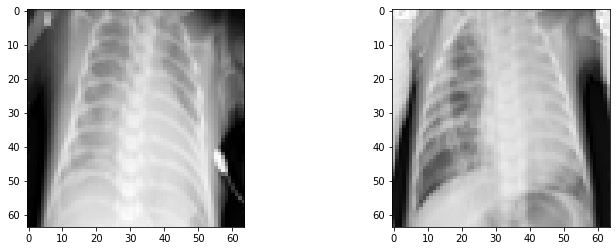

```python
# Dos exemples per cadascuna de les tres possibilitats.

hea=[]
cov=[]
pne=[]

for i in traindf.index:
    if traindf.loc[i,'Label']==0 and len(hea)<2:
        hea.append(traindf.loc[i,'Case'])
    elif traindf.loc[i,'Label']==1 and len(cov)<2:
        cov.append(traindf.loc[i,'Case'])
    elif traindf.loc[i,'Label']==2 and len(pne)<2:
        pne.append(traindf.loc[i,'Case'])
    if len(hea)==2 and len(cov)==2 and len(pne)==2:
        break

def pex(ex):
    plt.figure(figsize=(12, 4))
    plt.subplot(1, 2, 1)
    plt.imshow(ex[0], cmap='gray')
    plt.subplot(1, 2, 2)
    plt.imshow(ex[1], cmap='gray')
    plt.show()

print('Dos casos SANS____')
pex(hea)
print('Dos casos amb COVID____')
pex(cov)
print('Dos casos amb PNEUMONIA____')
pex(pne)
```

```python
# Gata augmentation mitjançant combinació de rotate(lleuger, entre 4-8 graus) i crop.
# Girarem totes les imatges cap a dreta i esquerra abans de fer el zoom, triplicant així les mostres per train.
# Finalment no farem servir flip per no donar caracteristiques errònies al model (el cos humà no és simètric).

def rota(img,ang):
    return(Image.fromarray(img).rotate(ang))
def flip(img):
    return(Image.fromarray(img).transpose(Image.FLIP_LEFT_RIGHT))
def crop(img):
    return(Image.fromarray(img).crop((round(size[0]*0.05), round(size[1]*0.05),
                                      round(size[0]*0.95), round(size[1]*0.95))).resize(size))

ang=4
dataug=pd.DataFrame(columns=['Case','Label'])
for i in traindf.index:
    img= np.array(crop(np.array(rota(traindf.loc[i,'Case'],ang))))
    dataug= dataug.append(pd.DataFrame([[img, traindf.loc[i,'Label']]],columns=['Case','Label']))
    img= np.array(crop(np.array(rota(traindf.loc[i,'Case'],-(12-ang)))))
    dataug= dataug.append(pd.DataFrame([[img, traindf.loc[i,'Label']]],columns=['Case','Label']))
    ang+=1
    if ang>8:
        ang=4

trainaug= traindf.append(dataug).sample(frac=1,random_state=42).reset_index(drop=True)
```

# Creació dels models i mètriques d'avaluació (3 punts)

En aquesta secció es demana desenvolupar el *pipeline* per a la creació i entrenament del/s model/s.

Es treballarà amb les dades de *training* i *validació*.

Caldrà tenir en compte aspectes com:

- Quina arquitectura és la més adecuada per resoldre aquest problema
- Quines mètriques cal utilitzar per mesurar de forma correcta el comportament del model
- Visualitzacions de les corbes d'entrenament/validació que ajudin a decidir quin model ha estat el millor i perquè
- Considerar un model *baseline* per poder comparar les mètriques (i.e. utilitzar prediccions aleatòries o fer servir un model naïve, com per exemple una xarxa neuronal amb poques capes)

```python
import keras
from keras.models import Sequential
from keras.layers import Dense, Conv2D, Flatten, Activation, Dropout, MaxPooling2D, BatchNormalization
from sklearn.preprocessing import OneHotEncoder
```

```python
# Definim x i y per cada dataset generat

def x_y(df):
    enc= OneHotEncoder(categories='auto')
    y= enc.fit_transform(np.array(df.Label).reshape(-1,1)).toarray()
    x=[]
    for i in df.Case:
        x.append(np.array(i).ravel())
    x= np.array(x).reshape(len(df.index),size[0],size[1],1)
    return(x,y)

x_train, y_train= x_y(trainaug)
x_val  , y_val  = x_y(valdf)
x_test , y_test = x_y(testdf)
```

```python
# Funció per plot del history.

def phistory(mod,fit):
    l=len(fit.history['loss'])
    plt.style.use('ggplot')
    plt.figure(figsize=(12, 4))

    plt.subplot(1, 2, 1)
    plt.plot(np.arange(0, l), fit.history['accuracy'], label='train_acc')
    plt.plot(np.arange(0, l), fit.history['val_accuracy'], label='val_acc')
    plt.xlabel('Epoch #')
    plt.ylabel('Accuracy')
    plt.legend(loc='lower right')

    plt.subplot(1, 2, 2)
    if fit.history['val_loss'][-1]>2:
        plt.ylim(0, 40)
    else:
        plt.ylim(0, 2)
    plt.plot(np.arange(0, l), fit.history['loss'], label='train_loss')
    plt.plot(np.arange(0, l), fit.history['val_loss'], label='val_loss')
    plt.xlabel('Epoch #')
    plt.ylabel('Loss')
    plt.legend(loc='upper right')
    plt.show()

    evm= mod.evaluate(x_val, y_val, verbose=1)
    print('Precisió del model:', evm[1],'\n')
    print('Pèrdua del model:', evm[0],'\n')
```

```python
# El problema no te un tamany excessivament gran en quant a mostres però sí pel que fa a paràmetres.
# Com a baseline per tant farem servir un model sequencial amb una sola capa convolucional amb pocs filtres i kernel de 3x3.
# L'activació per la capa de sortida serà softmax. Per les capes de Convolució i/o Full Connect serà relu.

baseline= Sequential()
baseline.add(Conv2D(24, kernel_size=3, activation="relu", input_shape=(size[0],size[1],1)))
baseline.add(Flatten())
baseline.add(Dense(3, activation="softmax"))

# Compilació amb optimizer Adam, loss categorical_crossentropy i metrics accuracy.
# Escollim un batch de 113 (el nombre arrel de la generació de mostres).
# Entrenarem el model durant 40 èpoques per poder comprovar l'evolució.

baseline.compile(optimizer='Adam', loss='categorical_crossentropy', metrics=['accuracy'])
bfit = baseline.fit(x_train, y_train, validation_data=(x_val, y_val), batch_size=113, epochs=40, verbose=0)
```

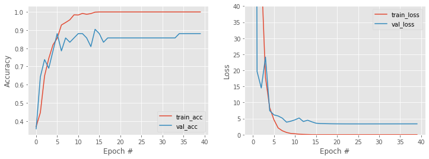

```
Precisió del model: 0.8809523582458496

Pèrdua del model: 3.3609047737859545
```

```python
phistory(baseline,bfit)
```

```python
# Els resultats del model base són prou bons pel que fa a l'accuracy, però l'error és molt alt.
# El model base també arriba al punt de deixar de aprendre, degut al baix nombre capes/filtres.
# El bon resultat indica que el model sequencial convolucional amb un nombre de filtres reduit és adequat pel problema.
# El baix nombre de filtres, juntament amb maxpooling i dropout, haurien de controlar la pèrdua i la possibilitat d'overfit.

cnn1= Sequential()
cnn1.add(Conv2D(24, kernel_size=3, activation="relu", input_shape=(size[0],size[1],1)))
cnn1.add(Conv2D(48, kernel_size=3, activation="relu"))
cnn1.add(MaxPooling2D((2,2), strides=2))
cnn1.add(Dropout(0.25))
cnn1.add(Flatten())
cnn1.add(Dense(128, activation='relu'))
cnn1.add(Dropout(0.5))
cnn1.add(Dense(3, activation="softmax"))

cnn1.compile(optimizer='Adam', loss='categorical_crossentropy', metrics=['accuracy'])
c1fit= cnn1.fit(x_train, y_train, validation_data=(x_val, y_val), batch_size=113, epochs=40, verbose=0)
```

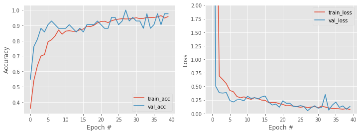

```
Precisió del model: 0.976190447807312

Pèrdua del model: 0.13017483339423225
```

```python
phistory(cnn1,c1fit)
```

```python
# Provarem amb un nombre major de filtres i afegint strides a la capa de convolució, per velocitat i reducció de overfit.

cnn2= Sequential()
cnn2.add(Conv2D(64, kernel_size=3, strides=2, activation="relu", input_shape=(size[0],size[1],1)))
cnn2.add(Conv2D(128, kernel_size=3, strides=2, activation="relu"))
cnn2.add(MaxPooling2D((2,2), strides=2))
cnn2.add(Dropout(0.25))
cnn2.add(Flatten())
cnn2.add(Dense(128, activation='relu'))
cnn2.add(Dropout(0.5))
cnn2.add(Dense(3, activation="softmax"))

cnn2.compile(optimizer='Adam', loss='categorical_crossentropy', metrics=['accuracy'])
c2fit = cnn2.fit(x_train, y_train, validation_data=(x_val, y_val), batch_size=113, epochs=40, verbose=0)
```

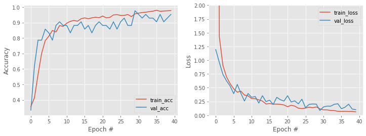

```
Precisió del model: 0.9523809552192688

Pèrdua del model: 0.1001942464638324
```

```python
phistory(cnn2,c2fit)
```

```python
# També seria possible ampliar el model a una petita arquitectura vgg.
# Per tal d'evitar overfit afegirem BatchNormalization a les capes d'activació, a més del maxpool+dropout.

vgg = Sequential()

# primer convolucional
vgg.add(Conv2D(24, kernel_size=3, activation="relu", input_shape=(size[0],size[1],1)))
vgg.add(BatchNormalization(axis=-1))
vgg.add(Conv2D(24, kernel_size=3, activation="relu"))
vgg.add(BatchNormalization(axis=-1))
vgg.add(MaxPooling2D((2,2), strides=2))
vgg.add(Dropout(0.25))

# segon convolucional
vgg.add(Conv2D(48, kernel_size=2, activation="relu"))
vgg.add(BatchNormalization(axis=-1))
vgg.add(Conv2D(48, kernel_size=2, activation="relu"))
vgg.add(BatchNormalization(axis=-1))
vgg.add(MaxPooling2D((2,2), strides=2))
vgg.add(Dropout(0.25))

# primer dense
vgg.add(Flatten())
vgg.add(Dense(256, activation='relu'))
vgg.add(BatchNormalization(axis=-1))
vgg.add(Dropout(0.5))

# segon dense
vgg.add(Dense(128, activation='relu'))
vgg.add(BatchNormalization(axis=-1))
vgg.add(Dropout(0.5))

# sortida softmax
vgg.add(Dense(3, activation="softmax"))

vgg.compile(optimizer='Adam', loss='categorical_crossentropy', metrics=['accuracy'])
vfit = vgg.fit(x_train, y_train, validation_data=(x_val, y_val), batch_size=113, epochs=40, verbose=0)
```

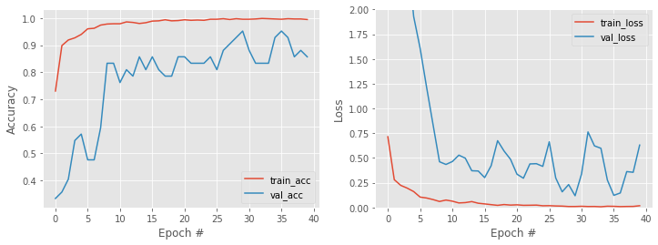

```
Precisió del model: 0.8571428656578064

Pèrdua del model: 0.6303224847430274
```

```python
phistory(vgg,vfit)
```

# Resultats i Conclusions (3 punts)

En aquesta secció cal implementar la fase de test dels millors models desenvolupats i entrenants en la fase anterior.

Es valoraran aspectes com:

- Raonament de quina arquitectura és la més adecuada
- Anàlisis quantitatiu i qualitatiu dels resultats

```python
def evtest(mod):
    evm= mod.evaluate(x_test, y_test, verbose=1)
    print('Precisió del model:', evm[1],'\n')
    print('Pèrdua del model:', evm[0],'\n')

print('Avaluació test de Baseline:\n')
evtest(baseline)
```

```
Avaluació test de Baseline:

Precisió del model: 0.8666666746139526

Pèrdua del model: 2.7077770233154297
```

- Degut al tractament de imatges que presenta el problema, resulta recomanable encarar-ho cap a una xarxa de convolució. Les entrades seràn ajustades a un tamany d'imatge adequat per resoldre el problema sense sobrecarregar innecesàriament de dades el model, de la mateixa manera que escollirem el mode Luminositat per treballar amb només una dimensió de profunditat.
- Com que les imatges segueixen totes el mateix patró, aquest es mantindrà tot el possible durant el data augmentation (nombre inicial de mostres baix per una cnn) per no 'confondre' al model amb angles extranys o simetries dels cosos alterades. La falta de detalls accessoris i de soroll a les imatges apunta a una baixa quantitat de capes per interpretar-les.
- Aquesta teoria resulta vàlida desde el moment en que una simple capa de convolució retorna resultats aptes, al menys fins a on arriba la seva capacitat d'aprenentatge. La capa convolucional té com a paràmetres uns reduïts 24 filtres, un kernel apropiat per la resolució de la imatge, i activacions relu i softmax per les capes corresponents. Completat el compile amb optimitzador Adam (adequat pel gran nombre de paràmetres), una crossentropy vàlida per les 3 sortides possibles, i una mètrica accuracy, el model baseline arriba a més d'un 80% de precisió, tot i que amb un error extremadament alt.

```python
print('Avaluació test de CNN1:\n')
evtest(cnn1)
```

```
Avaluació test de CNN1:

Precisió del model: 0.9333333373069763

Pèrdua del model: 0.44165787171158527
```

- El següent pas és per tant afegir capes per generar una CNN completa, que consta de dues capes de convolució on incrementem el nombre de filtres, seguides de capes de maxpooling (2x2 i amb strides, adequat al tamany de la imatge) i dropout (entre .25 i .5), abans d'afegir una capa flatten per passar a la part fully-connected previa a la sortida. El ajustat nombre de filtres, juntament amb les capes de maxpooling i dropout, serveixen per evitar el sobreentrenament que trobaríem al model en cas de no fer-les servir.
- Els resultats per aquest model són molt bons, superant el 90% de precisió tant en validació com en test. A més la gràfica de pèrdua, tot i ser bastant accidentada (en part degut a que els conjunts de validació i test no són gaire grans), no mostra una clara tendència al sobreentrenament. El temps necessari per fer l'avaluació s'incrementa notablement respecte al baseline degut a la major complexitat de la xarxa, però encara es manté per sota del milisegon.

```python
print('Avaluació test de CNN2:\n')
evtest(cnn2)
```

```
Avaluació test de CNN2:

Precisió del model: 0.8666666746139526

Pèrdua del model: 0.3752663532892863
```

- Com a modificació possible afegim strides a les capes de convolució (a més de la ja present capa de maxpooling) per aconseguir un càlcul ràpid de resultats. Podem comprovar que, tot i incrementar el nombre de filtres per les convolucions, la gràfica de pèrdua encara evita la tendència al overfit.
- El resultat respecte a precisió és semblant al cas anterior encara que més imprecís i variable, però sens dubte molt més ràpid en el temps d'avaluació.

```python
print('Avaluació test de VGG:\n')
evtest(vgg)
```

```
Avaluació test de VGG:

Precisió del model: 0.9333333373069763

Pèrdua del model: 0.17467756780485313
```

# *Explainability* (1 punt)

Investiga sobre les tècniques que es fan servir per entendre les decicions d'una CNN. Per exemple, Els [Class Activation Maps](https://arxiv.org/pdf/1512.04150.pdf) (CAM)[4] són una modificació en l'arquitectura d'una CNN de classificació de imatges que ens permet visualitzar quines parts de la imatge es consideren per classificar una classe amb una determinada etiqueta. Variacions de les CAMS s'han aplicat recentment per entendre el comportament de les xarxes per detectar Covid19[8].

Una altre mètode és el popular [Deep Dream](https://deepdreamgenerator.com/)[11]. Aquest mètode, a part de generar imatges amb un estil bastant artístic/psicodèlic, serveix per entendre el tipus de característiques que una xarxa busca en la imatge d'entrada per classificar-la amb una determinada etiqueta.

Implementa alguna tècnica de visualització per intentar entendre les decisions de la CNN entrenada.

```
CAM model cnn1:
```

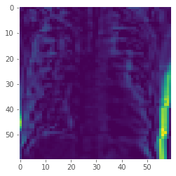

```
CAM model vgg:
```

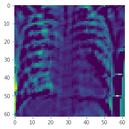

```python
from keras import backend as K

def cam(model,img):
    predict= model.predict(img)
    target_class= np.argmax(predict[0])

    grads= K.gradients(model.output[:,target_class], model.layers[1].output)[0]
    pooled_grads= K.mean(grads,axis=(0,1,2))
    iterate= K.function([model.input], [pooled_grads, model.layers[1].output[0]])
    pooled_grads_value,conv_layer_output = iterate([img])

    for i in range(24):
        conv_layer_output[:,:,i] *= pooled_grads_value[i]

    heatmap = np.mean(conv_layer_output,axis=-1)

    for x in range(heatmap.shape[0]):
        for y in range(heatmap.shape[1]):
            heatmap[x,y] = np.max(heatmap[x,y],0)

    heatmap = np.maximum(heatmap,0)
    heatmap /= np.max(heatmap)
    return(heatmap)

print('CAM model cnn1:')
plt.imshow(cam(cnn1,x_train))
plt.grid(None)
plt.show()
print('\nCAM model vgg:')
plt.imshow(cam(vgg,x_train))
plt.grid(None)
plt.show()
```

- A més profunditat més atenció pels detalls i les formes.
- El model cnn és massa bàsic per examinar la zona dels pulmons com es podria suposar. En aquest cas, amb un nombre de mostres reduït i una xarxa senzilla, podem veure que el model dóna més pes a factors perifèrics com si el pacient té algun tipus de cable conectat al seu voltant.